# A glimpse into the cosmic Class Corpus 2025

[figure not shown]

[figure not shown]

[figure not shown]

[figure not shown]

[figure not shown]

[figure not shown]

[figure not shown]

[figure not shown]

### My 2 musical aesteroids in the galaxy of Class Corpus 2025

My first song is an alternative punk song “Micro Pen” (‘elze-s-1.json’ in the corpus file), written, played and recorded by my band Common Sexuality. It’s a relatively short(1,40 sec), fast(165 BPM) and loud song.It was recorded live (each instrument separately) and mixed in FLStudio.

### Introduction to the musical universe of Class Corpus 2025

[interactive chart not shown]

On left you can see a scatter plot, which indicates the relationship between arousal, tempo and valence features in the Class Corpus 2025. Yellow dots are distributed mostly in the left top of the plot, which indicates that songs high in valence are also high in arousal and, surprisingly to me, have a slow tempo. The scarce distribution across the plot shows that the huge variety of songs in the corpus.Both of my songs, marked with labels in the scatter plot, are on the low in valence :(, which is to be expected from minors scales and alternative rock genre. “Micro Pen” seems to be the fastest song in the Class Corpus 2025, while “Random Fish’s Name” is in the average section. None of them are high in arousal, which could be affected by the low valence and ‘heaviness’ of rock genre.

### Songs entering self-similarity matrixes

#### Timbre-based self-similarity matrix of ‘Random Fish’s Name’

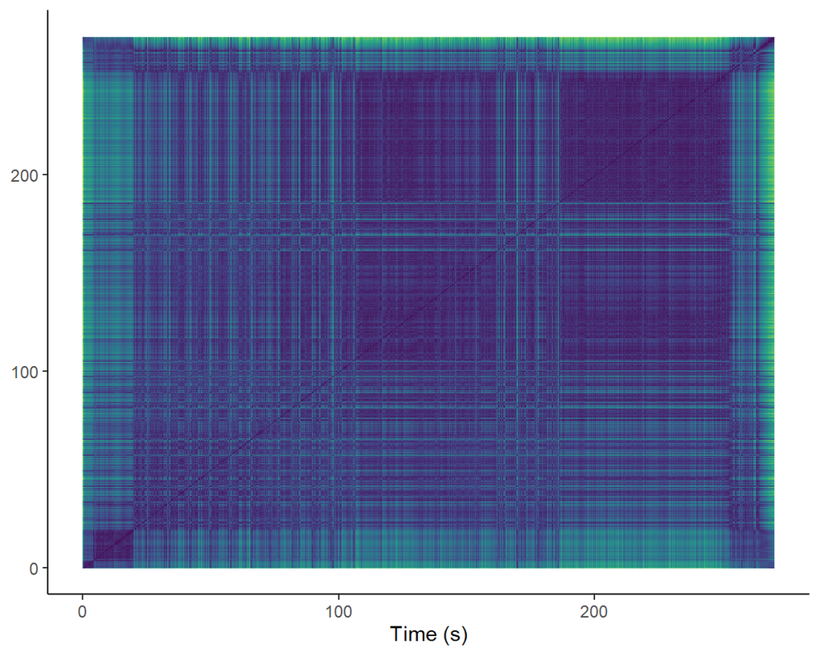

Above you can see the timbre based self-similarity matrix of my band’s song “Random Fish’s Name”. The song begins with sounds of crackling fireplace and water drops, which is constituted by the ‘small navy square’ in the left bottom corner. As the guitar joins in in the 20th second of the song, followed by vocals and ambient noises, the timbre becomes more varied. This variation is increased even more when bass and drums comes in, expanding the sphere of timbre even more with added low frequencies. The two ‘big navy squares’ in the top right show the timbre similarity of two verses and two choruses. The instruments (2 guitars, drums, bass and vocals) in all of them are not only the same but also perform almost identical parts, which is what makes those squares appear. The small gap between those squares indicates a guitar solo, which disrupts the timbre similarity.

#### Timbre-based self-similarity matrix of ‘Micro Pen’

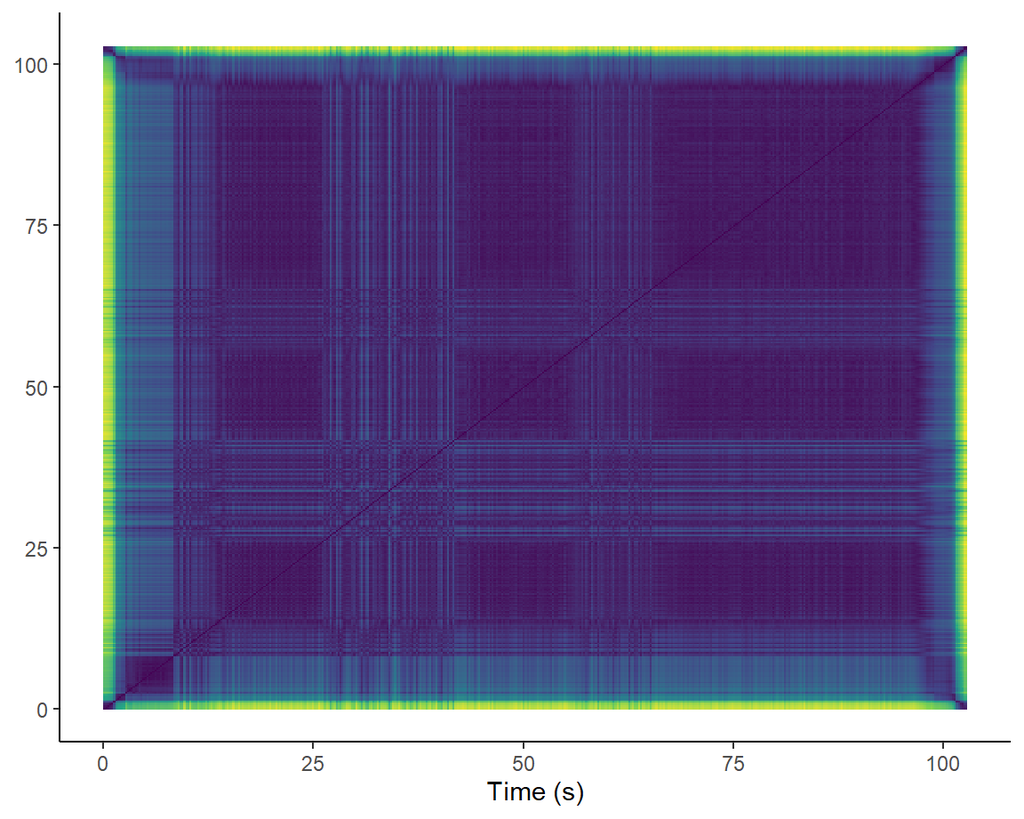

Above you can see the timbre based self-similarity matrix of my other song. It is clearly very similar to the previous self-similarity matrix. Both songs are of similar classical pop/rock structure, which consists of intro, verse, chorus, solo/bridge and outro, which is indicated by chekered pattern. The difference is that this song goes into chorus after the intro and only then follows the verse. Additionally, this song, in contrast to the previous one, does not possess ambient nature sounds, which results in less similarity disruption that is visible in the left bottom section of the previous matrix.

### How is energy distributed throughout my songs?

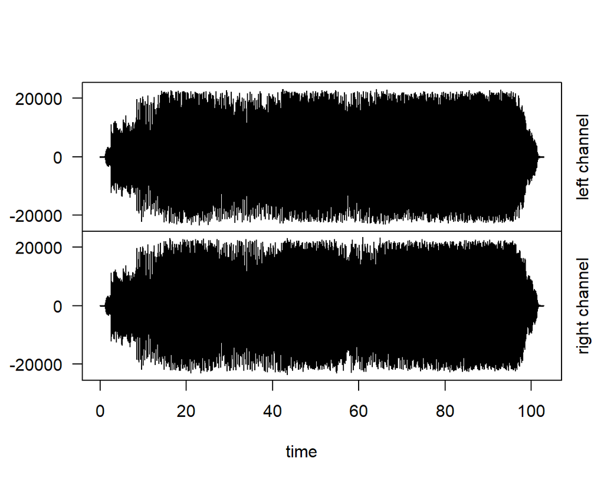

Energy in the first song ‘Micro pen’ (elze-s-1.json) is distributed evenly. The intro is slightly quieter than the rest of the song, which is clearly visible in the visualization. Since it is a punk song, the energy is overall high.

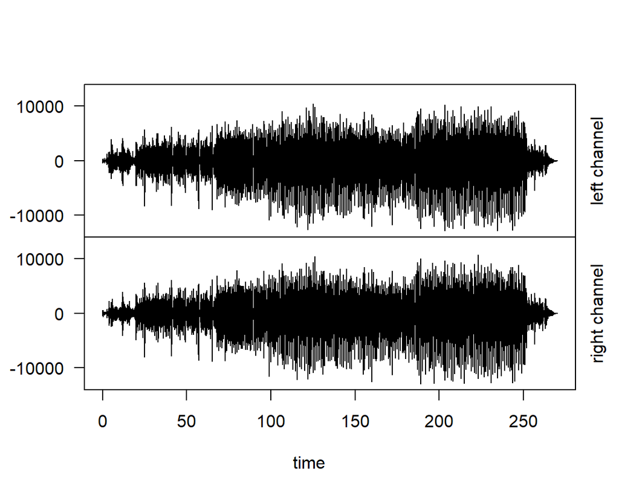

In contrast to the previous song, “Random Fish’s Name” has lower energy. It ‘swells-up’ from ambient sounds, intro and verse into the chorus, then descends in the second verse and increases in the chorus and solo to go down in the outro.

### What chroma values are colouring the surfaces of my musical space objects?

#### Chromagram of “Micro Pen”

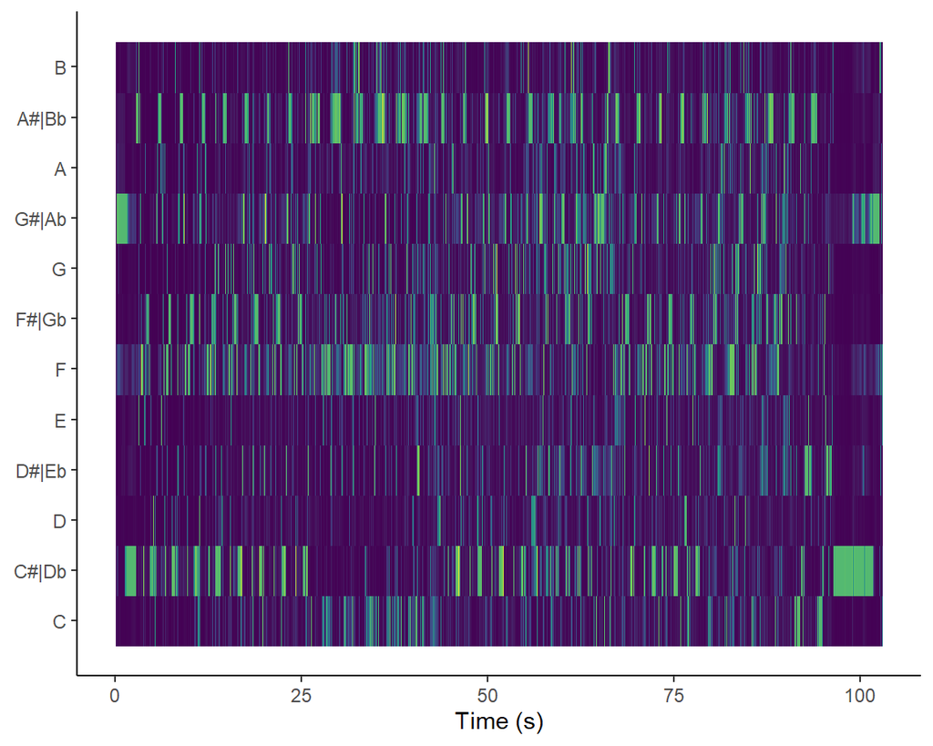

The chromagram above showcases crealy that the song is in A sharp minor key. The degrees of most prevalent notes are I (A#), III (C#), V (F/E#), VI(F#) and VII(G#). It slightly transgresses the usual rock/pop genre’s structure of I, IV,V and VI, but, nevertheless, is strongly based in its main tonality.

#### Chromagram of “Random Fish’s Name”

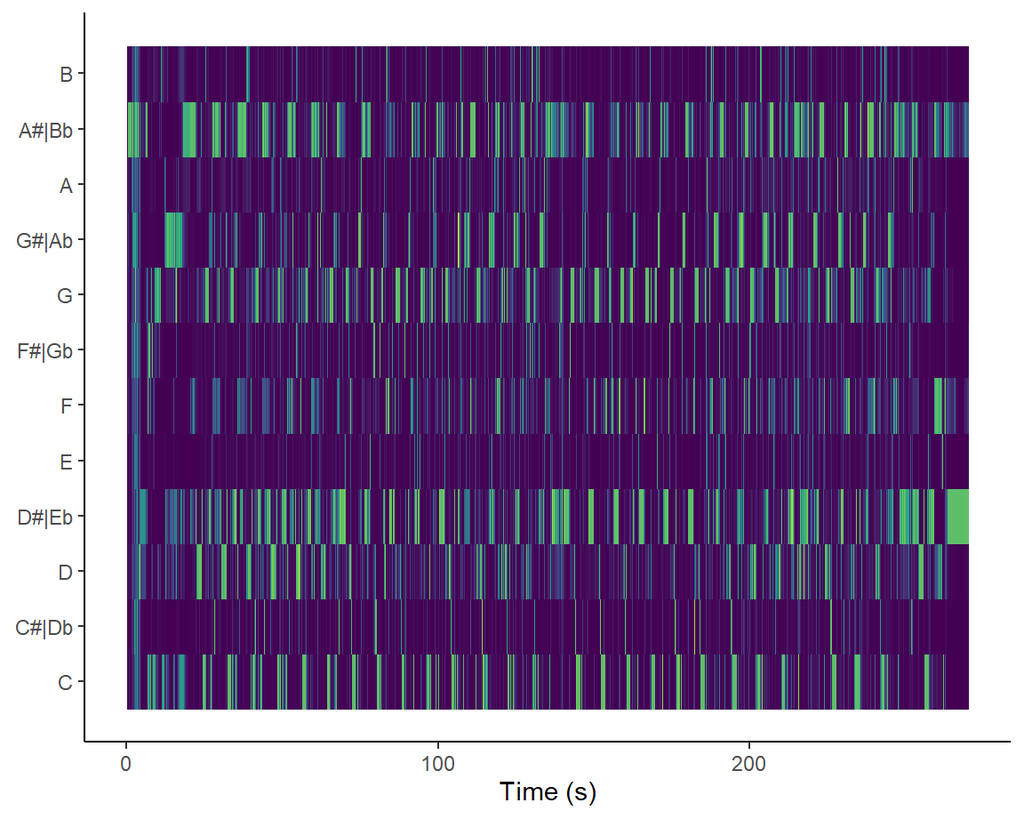

The song is in Eb major scale, which is clearly visible in the chromagram. It revolves around C minor,Ab major and Bb major chords, which follows a classic rock chord pattern of I, IV, V and VI degrees.

### How fast are my musical asteroids orbiting?

#### Cyclical tempogram of “Random Fish’s Name”

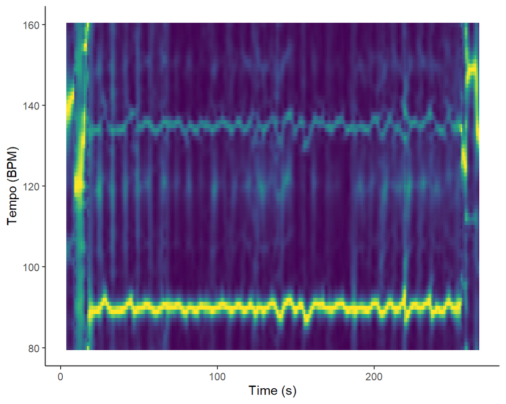

The cyclical tempogram above indicates a relatively stable tempo,excluding the beginning and the ending of the song. The BPM is around 90BPM, which is considered one of the most popular tempos in music as it matches the rate average rate of heartbeat. The fluctuation of tempo seen in the beginning and the end is caused by the usage of ambient sounds, which are not following a stable tempo.

#### Non-cyclical tempogram of “Micro Pen”

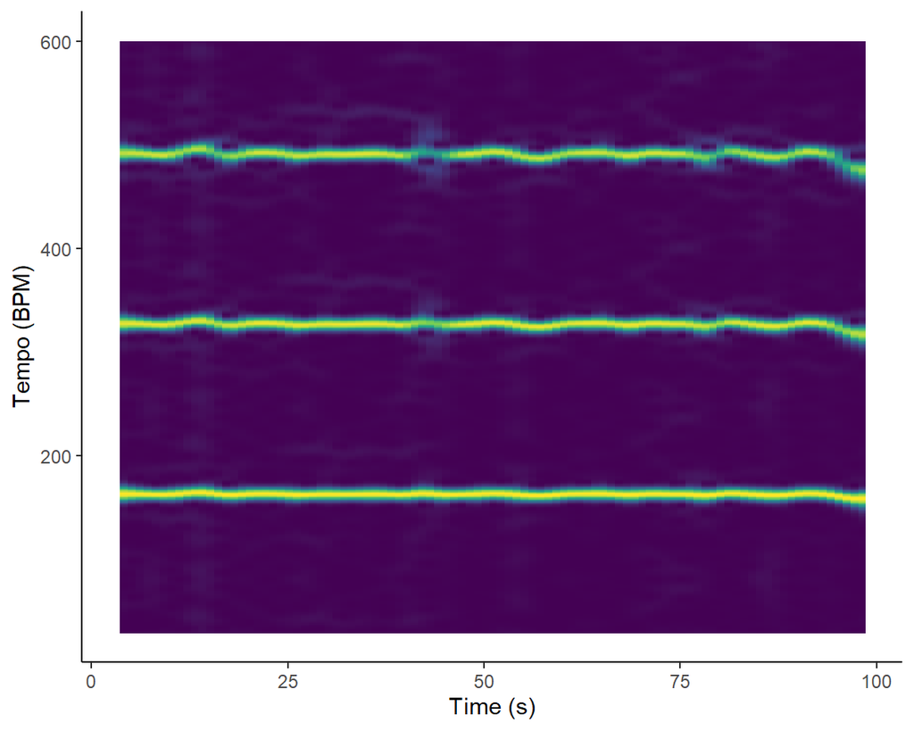

### Cosmic clusters in the universe of Class Corpus 2025

[interactive chart not shown]

My track ‘elze-s-1’ (Micro Pen) was clustered with tracks ‘senn-v-2’,‘lennart-p-2’ and ‘tobias-p-2’.All of these tracks are in a similar tempo. Since my track has hi-hat in sixteenth notes, as opposed to others having more 8th note feel (except maybe Tobia’s song, in which kick drum is playing sixteenth note patterns), it seems faster when the tempo is actually the same. The key of the songs seems to be the same or close as well.

My other track ‘elze-s-2’ (Random Fish’s Name) has been clustered with ‘mees-k-2’. It surprised me because these songs have completely different feels: mine seems to be calming, while Mees’s intensifying. However, after more in depth listening I noticed a some-what similarity in their instrumentalists and tempo.

### Concluding observations of galaxy Class Corpus 2025

To conclude, my songs “Random Fish’s Name” and “Micro Pen” are canonical rock songs with a stable tempo, tonal chroma feature, high or slightly fluctuating energy, and simple verse-chorus-solo structure. Compared to the variety of songs of my peers, my songs were clustered with the ones that also possess rock genre’s elements like constant hi-hat or overall ‘heaviness’. “Mirco Pen” sticks out for its fast punk tempo (165BPM).